# Fit PK data in R

# 1 Packages

```r
library(minqa)
library(RcppDE)
library(ggplot2)
library(mrgsolve)
library(dplyr)
library(purrr)
```

# 2 Fit simple, single-subject PK data `R`

Go to the `Theoph` data set for an example

- The `exTheoph` data set gets shipped with `mrgsolve`

```r
data(exTheoph)
```

We’ll just pick off the first `ID` to fit

```r
data <- filter(exTheoph, ID==1)
obs  <- filter(data, evid==0)
dose <- filter(data, evid==1)
```

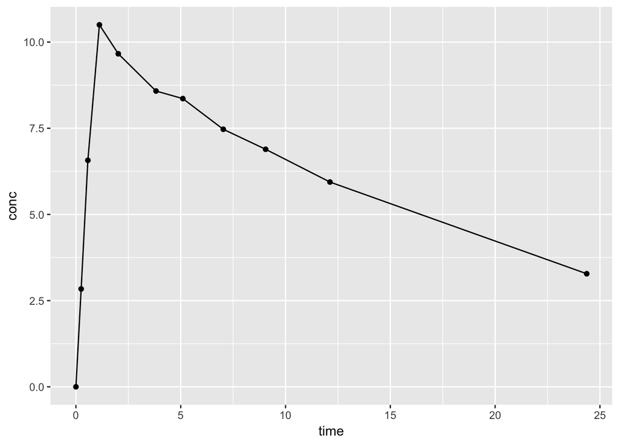

```r
qplot(data=data, time,conc, geom=c("line", "point"))
```

These are the observed data

```r
yobs <- obs$conc %>% unlist %>% unname
yobs
```

```
.  [1]  2.84  6.57 10.50  9.66  8.58  8.36  7.47  6.89  5.94  3.28
```

I’m going to capture them as a just a vector of values for now.

Like in the warmup vignette, we create a function that takes care of getting the prediction and calculating the objective function (ols, here).

- `p` parameters
- `.mod` model object
- `.data` the estimation data set
- `.yobs` vector of observed data
- `pred` if `TRUE`, just return a prediction

```r
ols <- function(p, .mod, .data, .yobs, pred=FALSE) {

  p <- lapply(p, exp)

  .mod <- update(.mod, param=p)

  if(pred) {
    .data <- filter(.data, evid !=0)
    return(mrgsim(.mod,.data))
  }

  out <- mrgsim(.mod, data=.data, obsonly=TRUE)

  y.hat <- out$CP

  sum(c(y.hat-.yobs)^2)
}
```

The workflow is similar to the warmup vignette, but **some important differences**

1. We have the parameters on log scale here, so we need to untransform
2. We cannot use the parameters directly to get the prediction; we need to perform an `update` step to bring the parameter set being proposed by the optimizer into the model object
3. We use `mrgsim` to actually generate the prediction
   - What would happen if we simulated with `obsonly = FALSE`?
4. When we call `ols` with `pred = TRUE`, we can get the prediction

Pull a simple 1-cmt model from the library

```r
mod <- mread("pk1", modlib())
```

```r
see(mod)
```

```
.
. Model file:  pk1.cpp
.  $PARAM @annotated
.  CL   :  1 : Clearance (volume/time)
.  V    : 20 : Central volume (volume)
.  KA   :  1 : Absorption rate constant (1/time)
.
.  $CMT  @annotated
.  EV   : Extravascular compartment
.  CENT : Central compartment
.
.  $GLOBAL
.  #define CP (CENT/V)
.
.  $PKMODEL ncmt = 1, depot = TRUE
.
.  $CAPTURE @annotated
.  CP : Plasma concentration (mass/volume)
```

Initial estimates; we’ll keep the parameters on log-scale

```r
theta <- log(c(CL=1, V=1, KA=0.1))
```

Let’s introduce a new optimizer from the `minqa` package called `newuoa`.

```r
fit <- minqa::newuoa(theta, ols, .mod = mod, .data=data, .yobs = yobs)

est <- setNames(fit$par, names(theta))

exp(fit$par)
```

```
. [1] 0.01992348 0.36926425 1.77741379
```

Get a prediction at the **final** estimate

```r
pred <-
  mod %>%
  update(end=25, delta=0.1) %>%
  ols(est,.,data,yobs,pred=TRUE) %>% as.data.frame
```

Get a prediction at the **initial** estimate

```r
pred_theta <-
  mod %>%
  update(end=25, delta=0.1) %>%
  ols(theta,.,data,yobs,pred=TRUE) %>%
  as_data_frame
```

Plot of observed data and data predicted at the initial and final estimates

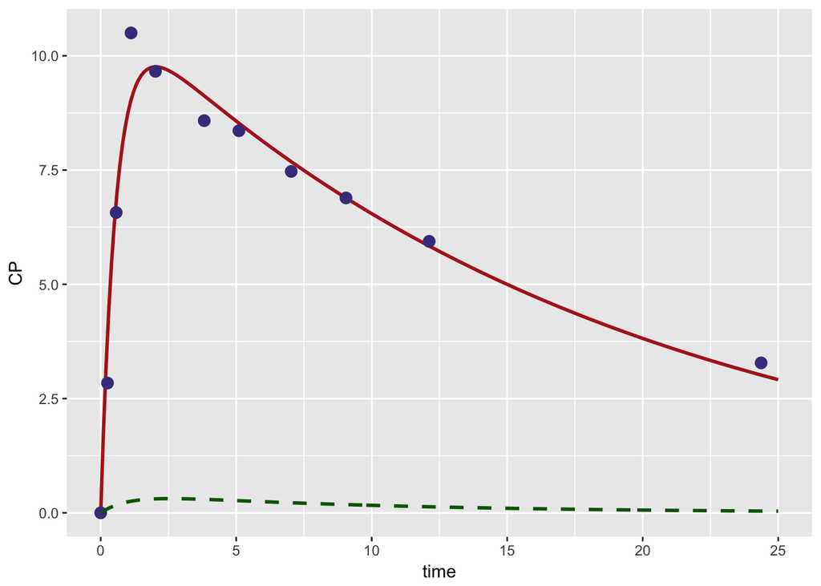

```r
ggplot() +
  geom_line(data=pred, aes(time,CP),lwd=1, col="firebrick") +
  geom_point(data=data, aes(time,conc), size=3, col="darkslateblue") +
  geom_line(data=pred_theta, aes(time,CP), lwd=1, lty=2,col="darkgreen")
```

# 3 Speed up the simulation with `qsim`

```r
ols.q <- function(p,.mod,.e,.data,.yobs, pred=FALSE) {

  p <- lapply(p, exp)

  .mod <- update(.mod,param=p)

  if(pred) {
    .data <- filter(.data, evid!=0)
    return(mrgsim(.mod,.data))
  }

  out <- qsim(.mod, .e)

  y.hat <- out[,"CP"]

  sum(c(y.hat-.yobs)^2)
}
```

```r
datam <- recmatrix(as.ev(dose),times=obs$time)
yhat <- qsim(mod,datam)
```

## 3.1 Benchmark

```r
e1 <- expression(newuoa(theta,ols.q,.mod=mod,.e=datam,.data=data,.yobs=yobs))
e2 <- expression(newuoa(theta,ols,.mod=mod,.data=data,.yobs=yobs))

rbenchmark::benchmark(eval(e1), eval(e2),replications=5)[,1:4]
```

```
.       test replications elapsed relative
. 1 eval(e1)            5   1.474     1.00
. 2 eval(e2)            5   3.081     2.09
```

# 4 The optimhelp package

This is in progress, but I almost always use it when working problems of any size.

We can make a “set” of parameters like this

```r
library(optimhelp)


cl <- log_par("CL", 1)
vc <- log_par("VC", 10)

p <- parset(cl,vc)
```

```r
p
```

```
.  name value transf tr fx
.    CL     1    log  u
.    VC    10    log  u
```

So we have two parameters (`CL` and `VC`) with parameters (1 and 10) and they are both on log scale.

To start an estimation problem, call

```r
initials(p)
```

```
.       CL       VC
. 0.000000 2.302585
```